# Big Mart Sales

Import all the libraries

```python
import numpy as np
import pandas as pd
import matplotlib.pyplot as plt
import seaborn as sns
import warnings
warnings.filterwarnings("ignore")
```

```python
# load the dataset
df = pd.read_csv('Big Mart sales.csv')
df.head(10)
```

|  | Item_Identifier | Item_Weight | Item_Fat_Content | Item_Visibility | Item_Type | Item_MRP | Outlet_Identifier | Outlet_Establishment_Year | Outlet_Size | Outlet_Location_Type | Outlet_Type | Item_Outlet_Sales |
| --- | --- | --- | --- | --- | --- | --- | --- | --- | --- | --- | --- | --- |
| 0 | FDA15 | 9.300 | Low Fat | 0.016047 | Dairy | 249.8092 | OUT049 | 1999 | Medium | Tier 1 | Supermarket Type1 | 3735.1380 |
| 1 | DRC01 | 5.920 | Regular | 0.019278 | Soft Drinks | 48.2692 | OUT018 | 2009 | Medium | Tier 3 | Supermarket Type2 | 443.4228 |
| 2 | FDN15 | 17.500 | Low Fat | 0.016760 | Meat | 141.6180 | OUT049 | 1999 | Medium | Tier 1 | Supermarket Type1 | 2097.2700 |
| 3 | FDX07 | 19.200 | Regular | 0.000000 | Fruits and Vegetables | 182.0950 | OUT010 | 1998 | NaN | Tier 3 | Grocery Store | 732.3800 |
| 4 | NCD19 | 8.930 | Low Fat | 0.000000 | Household | 53.8614 | OUT013 | 1987 | High | Tier 3 | Supermarket Type1 | 994.7052 |
| 5 | FDP36 | 10.395 | Regular | 0.000000 | Baking Goods | 51.4008 | OUT018 | 2009 | Medium | Tier 3 | Supermarket Type2 | 556.6088 |
| 6 | FDO10 | 13.650 | Regular | 0.012741 | Snack Foods | 57.6588 | OUT013 | 1987 | High | Tier 3 | Supermarket Type1 | 343.5528 |
| 7 | FDP10 | NaN | Low Fat | 0.127470 | Snack Foods | 107.7622 | OUT027 | 1985 | Medium | Tier 3 | Supermarket Type3 | 4022.7636 |
| 8 | FDH17 | 16.200 | Regular | 0.016687 | Frozen Foods | 96.9726 | OUT045 | 2002 | NaN | Tier 2 | Supermarket Type1 | 1076.5986 |
| 9 | FDU28 | 19.200 | Regular | 0.094450 | Frozen Foods | 187.8214 | OUT017 | 2007 | NaN | Tier 2 | Supermarket Type1 | 4710.5350 |

```python
#checking the data shape
df.shape
```

```
(8523, 12)
```

```python
#checking the data information
df.info()
```

```
<class 'pandas.core.frame.DataFrame'>
RangeIndex: 8523 entries, 0 to 8522
Data columns (total 12 columns):
 #   Column                     Non-Null Count  Dtype
---  ------                     --------------  -----
 0   Item_Identifier            8523 non-null   object
 1   Item_Weight                7060 non-null   float64
 2   Item_Fat_Content           8523 non-null   object
 3   Item_Visibility            8523 non-null   float64
 4   Item_Type                  8523 non-null   object
 5   Item_MRP                   8523 non-null   float64
 6   Outlet_Identifier          8523 non-null   object
 7   Outlet_Establishment_Year  8523 non-null   int64
 8   Outlet_Size                6113 non-null   object
 9   Outlet_Location_Type       8523 non-null   object
 10  Outlet_Type                8523 non-null   object
 11  Item_Outlet_Sales          8523 non-null   float64
dtypes: float64(4), int64(1), object(7)
memory usage: 799.2+ KB
```

```python
#lets find the stastics in the data
df.describe()
```

|  | Item_Weight | Item_Visibility | Item_MRP | Outlet_Establishment_Year | Item_Outlet_Sales |
| --- | --- | --- | --- | --- | --- |
| count | 7060.000000 | 8523.000000 | 8523.000000 | 8523.000000 | 8523.000000 |
| mean | 12.857645 | 0.066132 | 140.992782 | 1997.831867 | 2181.288914 |
| std | 4.643456 | 0.051598 | 62.275067 | 8.371760 | 1706.499616 |
| min | 4.555000 | 0.000000 | 31.290000 | 1985.000000 | 33.290000 |
| 25% | 8.773750 | 0.026989 | 93.826500 | 1987.000000 | 834.247400 |
| 50% | 12.600000 | 0.053931 | 143.012800 | 1999.000000 | 1794.331000 |
| 75% | 16.850000 | 0.094585 | 185.643700 | 2004.000000 | 3101.296400 |
| max | 21.350000 | 0.328391 | 266.888400 | 2009.000000 | 13086.964800 |

```python
#lets find the dtypes
df.dtypes
```

```
Item_Identifier               object
Item_Weight                  float64
Item_Fat_Content              object
Item_Visibility              float64
Item_Type                     object
Item_MRP                     float64
Outlet_Identifier             object
Outlet_Establishment_Year      int64
Outlet_Size                   object
Outlet_Location_Type          object
Outlet_Type                   object
Item_Outlet_Sales            float64
dtype: object
```

## Data cleaning process

** Firstly we check the null values if the data contain the null value drop the null value or replace with mean and mode values.

** Then we also check the duplicate values in the data set, if it contains duplicate drop it.

** Check the number of unique values in the each categorical columns in the data set.

** Check the data type of each columns.

```python
#lets check the null values
df.isnull().sum()
```

```
Item_Identifier                 0
Item_Weight                  1463
Item_Fat_Content                0
Item_Visibility                 0
Item_Type                       0
Item_MRP                        0
Outlet_Identifier               0
Outlet_Establishment_Year       0
Outlet_Size                  2410
Outlet_Location_Type            0
Outlet_Type                     0
Item_Outlet_Sales               0
dtype: int64
```

Item_weight have 1463 null values, Outlet_Size have 2410 null values.

```python
#lets find the mean and mode
print('Median :',df['Item_Weight'].median())
print('Mode :',df['Outlet_Size'].mode())
```

```
Median : 12.6
Mode : 0    Medium
Name: Outlet_Size, dtype: object
```

Item_Weight is the float data type so it can be replace by median, Outlet_Size is the object data type so replace with most repecting value(mode).

```python
#fill the null values
df['Item_Weight'].fillna(12.6,inplace = True)
df['Outlet_Size'].fillna('Medium',inplace = True)
```

Here I impute the null values by median and mode

```python
#check for null values after replace
df.isnull().sum()
```

```
Item_Identifier              0
Item_Weight                  0
Item_Fat_Content             0
Item_Visibility              0
Item_Type                    0
Item_MRP                     0
Outlet_Identifier            0
Outlet_Establishment_Year    0
Outlet_Size                  0
Outlet_Location_Type         0
Outlet_Type                  0
Item_Outlet_Sales            0
dtype: int64
```

```python
#check the duplicate values
df.duplicated().sum()
```

```
0
```

There is no duplicate value.

```python
#check for the number of unique value
df.nunique()
```

```
Item_Identifier              1559
Item_Weight                   415
Item_Fat_Content                5
Item_Visibility              7880
Item_Type                      16
Item_MRP                     5938
Outlet_Identifier              10
Outlet_Establishment_Year       9
Outlet_Size                     3
Outlet_Location_Type            3
Outlet_Type                     4
Item_Outlet_Sales            3493
dtype: int64
```

```python
#replace the values and convert into proper datatype
df['Outlet_Identifier']=df['Outlet_Identifier'].str.replace('OUT','')
df['Outlet_Identifier'].astype(int)
```

```
0       49
1       18
2       49
3       10
4       13
        ..
8518    13
8519    45
8520    35
8521    18
8522    46
Name: Outlet_Identifier, Length: 8523, dtype: int32
```

```python
df['Item_Fat_Content'].unique()
```

```
array(['Low Fat', 'Regular', 'low fat', 'LF', 'reg'], dtype=object)
```

```python
#replace the value into single value
df.replace(to_replace=['LF','low fat','reg'],
           value=['Low Fat','Low Fat','Regular'],inplace=True)
```

## Data Visualization

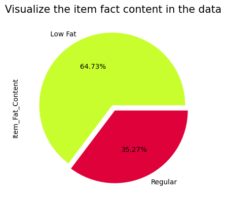

```python
#visualization the fact content in the data using pie chart
df['Item_Fat_Content'].value_counts().sort_values(ascending = False)\
.plot(kind='pie',explode=[0.03,0.05],
     labels=['Low Fat','Regular'],
     colors=['#C8FE2E','#DF013A'],
     autopct='%1.2f%%')
plt.title('Visualize the item fact content in the data',fontsize = 15)
plt.show()
```

most of the item have the Low Fat of 64.7% and regular is about only 35.27%.

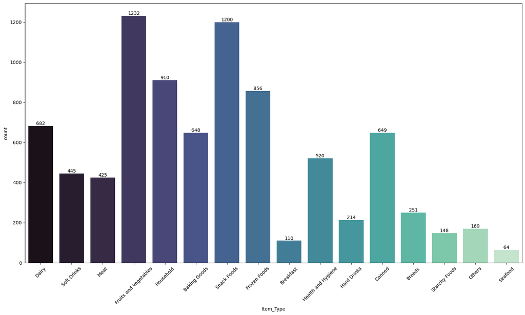

```python
plt.figure(figsize=(19,10))
c1=sns.countplot(x='Item_Type',data=df,palette="mako")
plt.xticks(rotation=45)
c1.bar_label(c1.containers[0],size = 10)
plt.show()
```

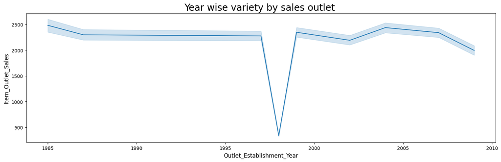

```python
# Year wise variety by sales outlet
plt.figure(figsize=(18,5))
sns.lineplot(data=df,x='Outlet_Establishment_Year', y= 'Item_Outlet_Sales')
plt.title('Year wise variety by sales outlet ', fontsize=20)
plt.xlabel('Outlet_Establishment_Year', fontsize=12)
plt.ylabel('Item_Outlet_Sales', fontsize=12)
plt.show()
```

In the year app around 1997 and 1998 there is huge lose in outlet sales, and in other years the outlet sales is app. constant.

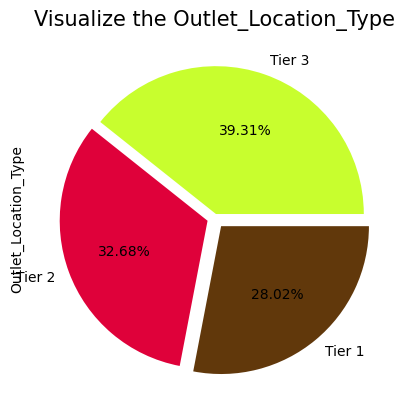

```python
#visualization the outlet_location_type
df['Outlet_Location_Type'].value_counts().sort_values(ascending = False)\
.plot(kind='pie',explode=[0.03,0.05,0.07],
     labels=['Tier 3','Tier 2','Tier 1'],
     colors=['#C8FE2E','#DF013A','#61380B'],
     autopct='%1.2f%%')
plt.title('Visualize the Outlet_Location_Type',fontsize = 15)
plt.show()
```

Tire 3 have more outlets location, and secondly tire 2 and tire 1 have the least count

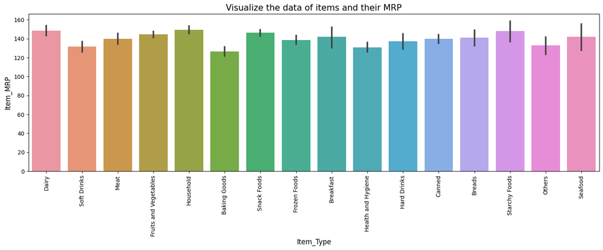

```python
# Category wise Item_Type and Item_MRP
plt.figure(figsize=(18,5))
sns.barplot(data=df, x='Item_Type', y= 'Item_MRP')
plt.title('Visualize the data of items and their MRP', size=15)
plt.xlabel('Item_Type', fontsize=12)
plt.ylabel('Item_MRP', fontsize=12)
plt.xticks(rotation=90)
plt.show()
```

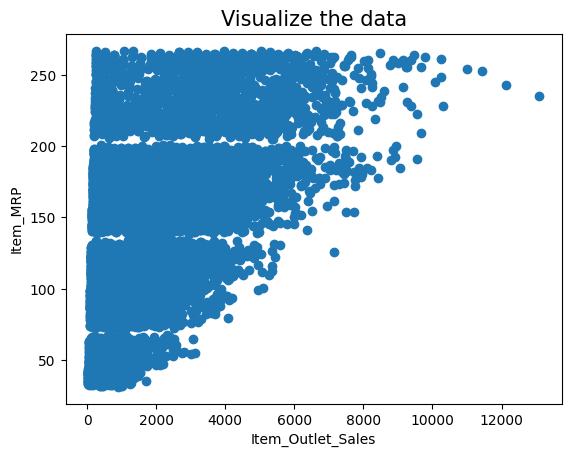

```python
#plot a scatter plot of item visibility and item MRP
plt.scatter(df['Item_Outlet_Sales'],df['Item_MRP'])
plt.title('Visualize the data', size=15)
plt.xlabel('Item_Outlet_Sales')
plt.ylabel('Item_MRP')

plt.show()
```

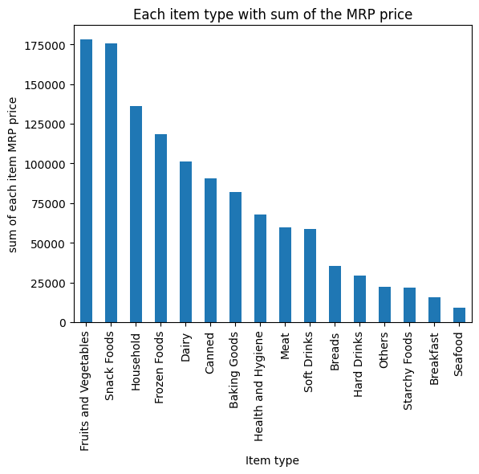

```python
#visualize the sum of the each item type with MRP price
df.groupby('Item_Type')['Item_MRP'].sum().sort_values(ascending=False)\
.plot(kind='bar')
colors=['mako']
plt.xlabel('Item type')
plt.ylabel('sum of each item MRP price')
plt.title('Each item type with sum of the MRP price')
plt.show()
```

The items like Friuts and vegetables, snack foods have the highest MRP price.

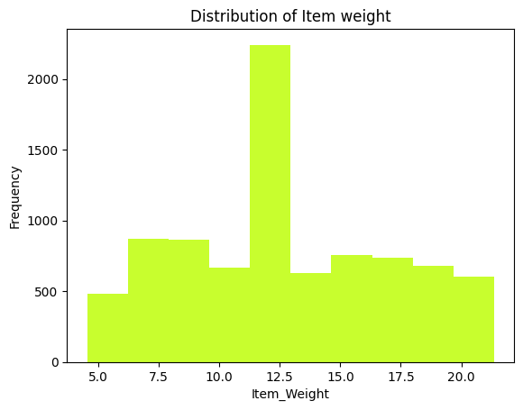

```python
#plot a histogram of item weight
plt.hist(df['Item_Weight'],bins=10,color='#C8FE2E')
plt.xlabel('Item_Weight')
plt.ylabel('Frequency')
plt.title('Distribution of Item weight')
plt.show()
```

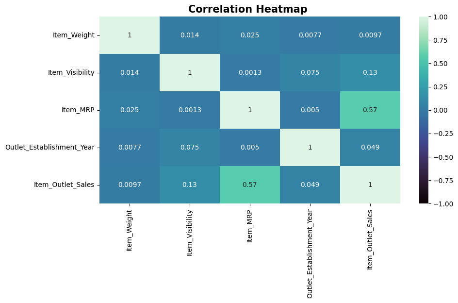

```python
#correlation heatmap
plt.figure(figsize=(10,5))
plot = sns.heatmap(abs(df.select_dtypes('number').corr()), annot=True, cmap='mako',vmin=-1)
plt.title('Correlation Heatmap ', weight='bold',fontsize=15)
plot.set_xticklabels(plot.get_xticklabels())
plot.set_yticklabels(plot.get_yticklabels())
plt.show()
```

## OutLayers

There may be many outlayers in the given data.

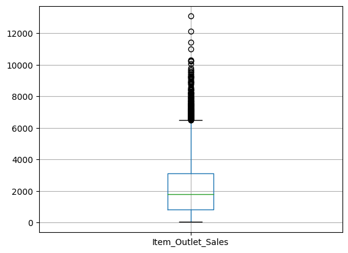

```python
df[['Item_Outlet_Sales']].boxplot()
```

```python
# for replacing
outliers=['Item_Outlet_Sales']
for i in outliers:
    q1=df[i].quantile(0.25)
    q3=df[i].quantile(0.75)
    IQR=q3-q1
    df.loc[df[i]>= q3 + 1.5 * IQR,i]=q3 + 1.5 * IQR
    df.loc[df[i]<= q1 - 1.5 * IQR,i]=q1 - 1.5 * IQR
```

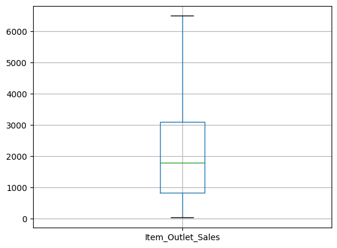

```python
df[['Item_Outlet_Sales']].boxplot()
```

hence we removed all the outlayers from the Item outlet sales.

```python
df.dtypes
```

```
Item_Identifier               object
Item_Weight                  float64
Item_Fat_Content              object
Item_Visibility              float64
Item_Type                     object
Item_MRP                     float64
Outlet_Identifier             object
Outlet_Establishment_Year      int64
Outlet_Size                   object
Outlet_Location_Type          object
Outlet_Type                   object
Item_Outlet_Sales            float64
dtype: object
```

## Machine Learning Modeling

First step we import all the required libraires.

Then convert the all categorical columns into numerical using LabelEncoder.

Then divided into data independent and dependent and do normalize the data.

Then we split the data into train and test data, we split it 25% and 75%.

We create a function for machine learning model.

Then apply Linear Regression.

Finaly predict the score.

```python
#import all required libaries for ML model
from sklearn.model_selection import train_test_split
from sklearn.preprocessing import LabelEncoder,StandardScaler
from sklearn.metrics import r2_score,mean_absolute_error,mean_squared_error
from sklearn.linear_model import  LinearRegression
from sklearn.preprocessing import LabelEncoder
```

```python
#select only the catcols
catcols = df.select_dtypes(include = 'object')
for i in catcols:
    print(i, ':', df[i].nunique())
    print(df[i].unique())
```

```
Item_Identifier : 1559
['FDA15' 'DRC01' 'FDN15' ... 'NCF55' 'NCW30' 'NCW05']
Item_Fat_Content : 2
['Low Fat' 'Regular']
Item_Type : 16
['Dairy' 'Soft Drinks' 'Meat' 'Fruits and Vegetables' 'Household'
 'Baking Goods' 'Snack Foods' 'Frozen Foods' 'Breakfast'
 'Health and Hygiene' 'Hard Drinks' 'Canned' 'Breads' 'Starchy Foods'
 'Others' 'Seafood']
Outlet_Identifier : 10
['049' '018' '010' '013' '027' '045' '017' '046' '035' '019']
Outlet_Size : 3
['Medium' 'High' 'Small']
Outlet_Location_Type : 3
['Tier 1' 'Tier 3' 'Tier 2']
Outlet_Type : 4
['Supermarket Type1' 'Supermarket Type2' 'Grocery Store'
 'Supermarket Type3']
```

```python
#select only the numerical columns
numcols = df.select_dtypes(include = 'float')
for i in numcols:
    print(i, ':', df[i].nunique())
```

```
Item_Weight : 415
Item_Visibility : 7880
Item_MRP : 5938
Item_Outlet_Sales : 3323
```

```python
#encode the given catcols
le = LabelEncoder()
for i in catcols:
    df[i] = le.fit_transform(df[i])
```

```python
#divided the data into dependent and independend variable
X = df.drop('Item_Outlet_Sales', axis = 1)
y = df['Item_Outlet_Sales']
```

```python
#Normarlize the data using the standerdscaler and transform data into 0 and 1
scaler = StandardScaler()
X=scaler.fit_transform(X)
#split the date into train and test data, we take 25% for test and 75% for train
X_train,X_test,y_train,y_test = train_test_split(X,y,test_size=0.25,random_state=45)
```

## Linear Regression

```python
linear = LinearRegression()
linear.fit(X_train, y_train)
```

```
LinearRegression()
```

```python
print('intercept :', linear.intercept_)   # to see the values of intercept "c"
```

```
intercept : 2157.1913861203075
```

```python
print('coef :', linear.coef_)  # to see the valus of coefficient "m"
```

```
coef : [-1.22051245e-01  4.01206149e+00  2.83553282e+01 -7.40063294e+01
  6.94240490e-01  9.35150723e+02  1.60838526e+02  1.93604968e+01
 -2.10564808e+02 -1.87482516e+02  6.75983439e+02]
```

```python
y_pred=linear.predict(X_test)
print('y_pred :',y_pred )
```

```
y_pred : [4400.7454623  1224.75439898 1986.42422406 ... 2609.52067504 3952.77388768
 2133.09837794]
```

```python
print('y_test :', y_test)
```

```
y_test : 4454    3410.2276
4743    1605.9096
3017     675.1212
5753    1662.5026
1478    4211.1850
          ...
2750    4458.1968
4955      83.8908
8408    2563.3300
4734    2302.3364
3928    2492.7552
Name: Item_Outlet_Sales, Length: 2131, dtype: float64
```

```python
#predict the test data
mae = mean_absolute_error(y_test,y_pred)
mse = mean_squared_error(y_test,y_pred)
r2 = r2_score(y_test,y_pred)
```

```python
print('MAE is',mae)
print('MSE is',mse)
print('r2 is',r2)
```

```
MAE is 891.9528375613006
MSE is 1340048.2845424507
r2 is 0.5075086575804059
```